# lab 3

## INFX574 Lab 3

#### Deadline: Wed, Apr 18, 11:59pm

Please submit the completed lab by end of the day. You should submit a) your code (notebooks, rmd, whatever) and b) the lab in a nal output form (html or pdf).  
Please do not just provide computer output. Always comment on your main ndings. Include any substantial comments as a separate text blocks. Also limit your output: do not submit pages and pages of whatever your code spits out.  
Note: you may want to do some of it on paper instead of computer. You are welcome to do it but please include the result as an image into your nal le.

## 1 Was Montana Meth Prevention Project Eective?

Your task is to determine if Montana Meth Prevention Project (MMP) was eective in decreasing the methamphetamine use among Montana teens.

```python
import numpy as np
import pandas as pd
import statsmodels.formula.api as smf
import matplotlib.pyplot as plt
%matplotlib inline
```

### Background and Data

2005-2007 Montana conducted an agressive ad campaign to decrease the meth abuse by the youth.  
Your task is to analyze the ecacy of the campaign using Youth Risk Behavior Surve (YRBS) data. You will implement a) cross-sectional estimator; b) before-after estimator; c) dierences-in-dierences (DiD) estimator. The sample, necessary for this lab, is on canvas. The full data and documentation can be obtained from https://www.cdc.gov/healthyyouth/data/yrbs/data.htm.

#### 1.1 Your Tasks

##### 1 Before-After

Load the data. Explore the data: what's it's dimension? How are variable coded? Are there any missings?  
Compute an additional variable: before the campaign (=2003, 2005) and after the campaign (=2007, 2009).

```python
# load the data
yrbs = pd.read_table('../lab_3/yrbs.tsv.bz2')
print(yrbs.head())
print(yrbs.shape)
print(yrbs.year.unique())
print(yrbs.age.unique())
print(yrbs.sex.unique())
print(yrbs.meth.unique())
print(yrbs.tv.unique())
print(yrbs.state.unique())

# add the campaign column
yrbs['before'] = np.where(yrbs['year']<=2005, 1, 0) # set before to 0 and set after to 1
print(yrbs.head())
```

```
   year  age sex  meth  tv state
0  2003   13   M     0   1    XX
1  2003   13   M     1   1    XX
2  2003   13   M     1   1    XX
3  2003   13   M     0   1    XX
4  2003   13   M     0   0    XX
(58077, 6)
[2003 2005 2007 2009]
[13 14 15 16 17]
['M' 'F']
[0 1]
[1 0]
['XX' 'MT']
   year  age sex  meth  tv state  before
0  2003   13   M     0   1    XX       1
1  2003   13   M     1   1    XX       1
2  2003   13   M     1   1    XX       1
3  2003   13   M     0   1    XX       1
4  2003   13   M     0   0    XX       1
```

##### 2 Graphical Exploration Plot the mean value of meth use for each year, separately for Montana and national sample. Comment your results.

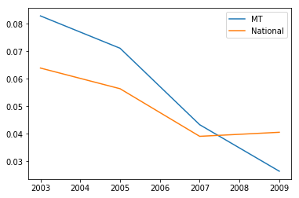

```python
ym = yrbs.groupby(['year', 'state']).meth.mean().reset_index()
plt.plot(ym.year[ym.state=='MT'], ym.meth[ym.state=='MT'], label='MT')
plt.plot(ym.year[ym.state=='XX'], ym.meth[ym.state=='XX'], label='National')
plt.legend()
```

##### comment:

**for Montana**, the mean value of meth use has been dropping from the year of 2003 to 2009

#### 3 Before-After Estimator Compare the meth use (mean value) in Montana before and after the campaign. In each case interpret the most important outcome.

1. Do it as a simple table
2. Do it using regression without any other controls
3. Run a regression with full controls (i.e. age, sex, tv).

```python
print(yrbs[yrbs.state == 'MT'].groupby('before').meth.mean())

m = smf.ols(formula = 'meth ~ before', data = yrbs[yrbs.state == 'MT'])
print(m.fit().summary())

m_full = smf.ols(formula = 'meth ~ age + sex + tv + before', data = yrbs[yrbs.state == 'MT'])
print(m_full.fit().summary())
```

```
before
0    0.038115
1    0.076734
Name: meth, dtype: float64
                            OLS Regression Results
==============================================================================
Dep. Variable:                   meth   R-squared:                       0.007
Model:                            OLS   Adj. R-squared:                  0.007
Method:                 Least Squares   F-statistic:                     67.66
Date:                Wed, 18 Apr 2018   Prob (F-statistic):           2.19e-16
Time:                        20:56:25   Log-Likelihood:                 417.76
No. Observations:                9754   AIC:                            -831.5
Df Residuals:                    9752   BIC:                            -817.1
Df Model:                           1
Covariance Type:            nonrobust
==============================================================================
                 coef    std err          t      P>|t|      [0.025      0.975]
------------------------------------------------------------------------------
Intercept      0.0381      0.003     11.484      0.000       0.032       0.045
before         0.0386      0.005      8.225      0.000       0.029       0.048
==============================================================================
Omnibus:                     7326.455   Durbin-Watson:                   1.957
Prob(Omnibus):                  0.000   Jarque-Bera (JB):            84570.020
Skew:                           3.765   Prob(JB):                         0.00
Kurtosis:                      15.304   Cond. No.                         2.62
==============================================================================

Warnings:
[1] Standard Errors assume that the covariance matrix of the errors is correctly specified.
                            OLS Regression Results
==============================================================================
Dep. Variable:                   meth   R-squared:                       0.009
Model:                            OLS   Adj. R-squared:                  0.009
Method:                 Least Squares   F-statistic:                     23.20
Date:                Wed, 18 Apr 2018   Prob (F-statistic):           4.11e-19
Time:                        20:56:25   Log-Likelihood:                 430.25
No. Observations:                9754   AIC:                            -850.5
Df Residuals:                    9749   BIC:                            -814.6
Df Model:                           4
Covariance Type:            nonrobust
==============================================================================
                 coef    std err          t      P>|t|      [0.025      0.975]
------------------------------------------------------------------------------
Intercept     -0.1476      0.038     -3.911      0.000      -0.222      -0.074
sex[T.M]      -0.0031      0.005     -0.653      0.514      -0.012       0.006
age            0.0118      0.002      4.953      0.000       0.007       0.016
tv             0.0035      0.005      0.739      0.460      -0.006       0.013
before         0.0386      0.005      8.221      0.000       0.029       0.048
==============================================================================
Omnibus:                     7302.251   Durbin-Watson:                   1.963
Prob(Omnibus):                  0.000   Jarque-Bera (JB):            83719.425
Skew:                           3.750   Prob(JB):                         0.00
Kurtosis:                      15.237   Cond. No.                         255.
==============================================================================

Warnings:
[1] Standard Errors assume that the covariance matrix of the errors is correctly specified.
```

##### comment:

**for Montana**, the mean value of meth use among teen has been dropped from 0.0767 to 0.0381 after the campaign, meaning that the campaign has a pretty positive effect, helping the teen to reduce the meth use.

based on the meth ~ before linear regression result, we can confirm the pattern of what we seen from the previous question, the avg use of meth among teen reduced after the campaign is issued

based on the full variable regression result, we can see that there is a negative correlation between meth use mean and gender, positive correlation between use and age, tv, and campaign. However, the correlation is relatively small and we can neglect the effect of tv and gender.

#### 4 Cross-Sectional Estimator Compare the meth use (mean value) in Montana and nationally after the project. In each case interpret the results.

- Do it as a simple table
- Do it using regression without any other controls
- Run a regression with full controls.

```python
print(yrbs[yrbs.before == 0].groupby('state').meth.mean())

m1 = smf.ols(formula = 'meth ~ before', data = yrbs[yrbs.before == 0])
print(m1.fit().summary())

m1_full = smf.ols(formula = 'meth ~ age + sex + tv + before', data = yrbs[yrbs.before == 0])
print(m1_full.fit().summary())
```

[output not shown]

##### comment:

based on the full variable regression result, we can see that there is a negative correlation between meth use mean and tv. However, the correlation is too small and we can neglect the effect of tv.

#### 5 Dierences-in-Dierences Estimator Compare the dierences in trends in meth use in Montana and nationally between pre-project and post-project years. In each case interpret the results.

- Do it as a simple table: report average use before and after the campaign in both Montana and nationally. Compute the eect by calculating the trend dierence.
- Do it using regression without any other controls
- Run a regression with full controls.

```python
print(yrbs.groupby(['state', 'before']).meth.mean())

m2 = smf.ols(formula = 'meth ~ state*before', data = yrbs)
print(m2.fit().summary())

m2_full = smf.ols(formula = 'meth ~ state*before + age + sex + tv', data = yrbs)
print(m2_full.fit().summary())
```

```
state  before
MT     0         0.038115
       1         0.076734
XX     0         0.039923
       1         0.060319
Name: meth, dtype: float64
                            OLS Regression Results
==============================================================================
Dep. Variable:                   meth   R-squared:                       0.003
Model:                            OLS   Adj. R-squared:                  0.003
Method:                 Least Squares   F-statistic:                     62.92
Date:                Wed, 18 Apr 2018   Prob (F-statistic):           1.31e-40
Time:                        21:13:20   Log-Likelihood:                 5566.9
No. Observations:               58077   AIC:                        -1.113e+04
Df Residuals:                   58073   BIC:                        -1.109e+04
Df Model:                           3
Covariance Type:            nonrobust
======================================================================================
                         coef    std err          t      P>|t|      [0.025      0.975]
--------------------------------------------------------------------------------------
Intercept              0.0381      0.003     12.110      0.000       0.032       0.044
state[T.XX]            0.0018      0.003      0.525      0.599      -0.005       0.009
before                 0.0386      0.004      8.674      0.000       0.030       0.047
state[T.XX]:before    -0.0182      0.005     -3.733      0.000      -0.028      -0.009
==============================================================================
Omnibus:                    46583.747   Durbin-Watson:                   1.971
Prob(Omnibus):                  0.000   Jarque-Bera (JB):           670089.493
Skew:                           4.057   Prob(JB):                         0.00
Kurtosis:                      17.528   Cond. No.                         12.2
==============================================================================

Warnings:
[1] Standard Errors assume that the covariance matrix of the errors is correctly specified.
                            OLS Regression Results
==============================================================================
Dep. Variable:                   meth   R-squared:                       0.005
Model:                            OLS   Adj. R-squared:                  0.004
Method:                 Least Squares   F-statistic:                     44.37
Date:                Wed, 18 Apr 2018   Prob (F-statistic):           1.87e-54
Time:                        21:13:20   Log-Likelihood:                 5605.5
```

[output cut: 8 more lines]

```
state[T.XX]            0.0018      0.003      0.521      0.602      -0.005       0.009
sex[T.M]               0.0064      0.002      3.486      0.000       0.003       0.010
before                 0.0389      0.004      8.740      0.000       0.030       0.048
state[T.XX]:before    -0.0185      0.005     -3.785      0.000      -0.028      -0.009
age                    0.0070      0.001      7.630      0.000       0.005       0.009
tv                    -0.0041      0.002     -2.154      0.031      -0.008      -0.000
==============================================================================
Omnibus:                    46508.899   Durbin-Watson:                   1.973
Prob(Omnibus):                  0.000   Jarque-Bera (JB):           666670.662
Skew:                           4.049   Prob(JB):                         0.00
Kurtosis:                      17.489   Cond. No.                         259.
==============================================================================

Warnings:
[1] Standard Errors assume that the covariance matrix of the errors is correctly specified.
```

##### comment:

the diff_in_diff for Montana and National is (0.076734 - 0.038115) - (0.060319 - 0.039923).  
the diff_in_diff for before and after campaign is (0.076734 - 0.060319) - (0.038115 - 0.039923).